# R-DAVIS Final Assignment

Elizabeth Mojica

3/11/2020

Loading three dataframes into R

```r
flights <- read_csv("data/raw_data/nyc_13_flights.csv") %>%
  select(-c(X18, X19))
planes <- read_csv("data/raw_data/nyc_13_planes.csv")
weather <- read_csv("data/raw_data/nyc_13_weather.csv")

flights$sched_dep_time <- as.numeric(flights$sched_dep_time)
```

Part 1: Plot the departure delay of flights against the precipitation, and include a simple regression line as part of the plot. Hint: there is a geom_ that will plot a simple y ~ x regression line for you, but you might have to use an argument to make sure it’s a regular linear model.

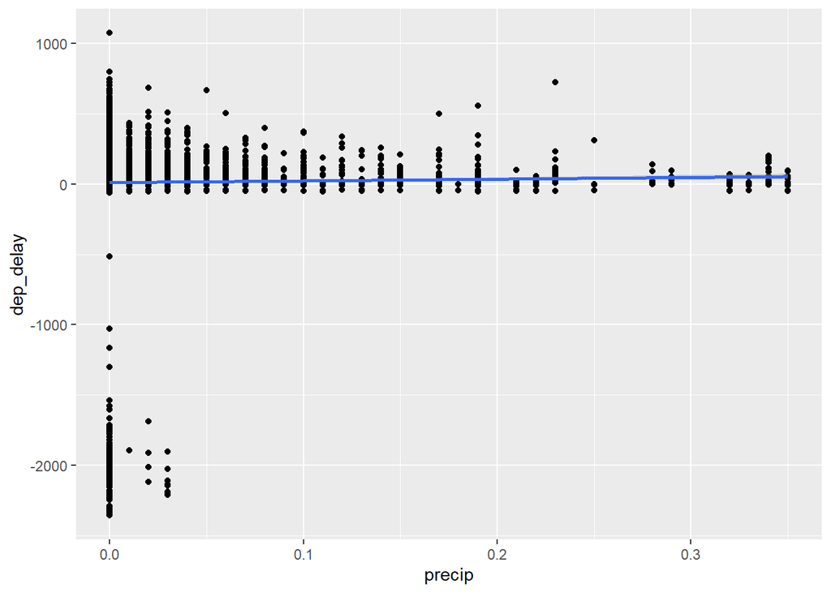

```r
flights$time_hour <- paste0(flights$year, sep = "-", flights$month, sep = "-", flights$day, sep = " ", flights$hour)
flights$time_hour <- ymd_h(flights$time_hour)

flights$dep_delay <- flights$dep_time - flights$sched_dep_time

flights_weather <- left_join(flights, weather, by = c("time_hour", "origin"))

flights_weather %>%
  filter(complete.cases(.)) %>%
  ggplot(mapping = aes(x = precip, y = dep_delay)) +
  geom_point() +
  geom_smooth(method = "lm")
```

Part 2: Create a figure that has date on the x axis and mean departure delay on the y axis. Plot only months September through December. Somehow distinguish between airline carriers (the method is up to you). Hint: You have the columns sched_dep_time (scheduled departure time) and dep_time (the actual departure time). Calculate the difference for the departure delay.

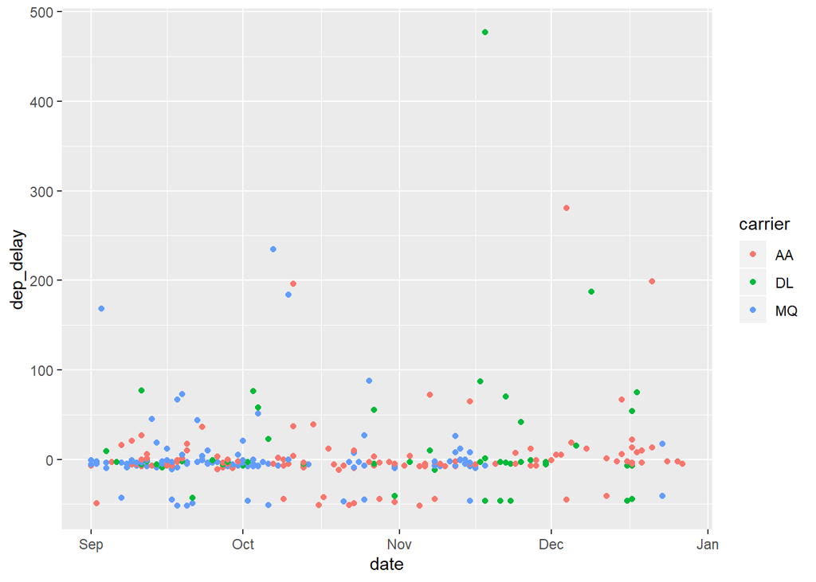

```r
flights$date <- paste0(flights$year, sep = "-", flights$month, sep = "-", flights$day)
flights$date <- ymd(flights$date)

flights$dep_delay <- flights$dep_time - flights$sched_dep_time

flights_planes <- left_join(flights, planes, by = c("tailnum"))
flights_planes <- flights_planes %>%
  filter(complete.cases(.)) %>%
  filter(month == 9 | month == 10 | month == 11 | month == 12)

flights_planes %>%
  ggplot(mapping = aes(x = date, y = dep_delay, color = carrier)) +
  geom_point()
```

Part 3: Create a table with these columns: date (year, month and day), mean_temp_EWR, mean_temp_JFK, mean_temp_LGA. Notice the names share a prefix, wonder if there’s an argument somewhere for that… Also, it’s a lot of data, so think about whether you want a really long table or an interactive one you can click through (check out the RMarkdown lesson if you need help).

```r
flights_weather_planes <- left_join(flights_weather, planes, by = "tailnum")
flights_weather_planes$date <- paste0(flights_weather_planes$year.x, sep = "-", flights_weather_planes$month.x, sep = "-", flights_weather_planes$day.x)
flights_weather_planes$date <- ymd(flights_weather_planes$date)

table_data <- flights_weather_planes %>%
  group_by(date, carrier) %>%
  summarize(mean_temp = mean(temp))

DT::datatable(table_data)
```

|  | date | carrier | mean_temp |
| --- | --- | --- | --- |
| 1 | 2013-01-01 | 9E |  |
| 2 | 2013-01-01 | AA |  |
| 3 | 2013-01-01 | AS | 39.11 |
| 4 | 2013-01-01 | B6 |  |
| 5 | 2013-01-01 | DL |  |
| 6 | 2013-01-01 | EV |  |
| 7 | 2013-01-01 | F9 | 39.47 |
| 8 | 2013-01-01 | FL | 39.758 |
| 9 | 2013-01-01 | HA | 39.92 |
| 10 | 2013-01-01 | MQ |  |

[output cut: 5422 more lines]

Part 4: Make a combination violin/scatterplot showing departure delay by manufacturer, and add a facet for whether or not it’s raining. Hint: you’ll have to make a new column to classify “raining” or “not raining”, the exact method is up to you.

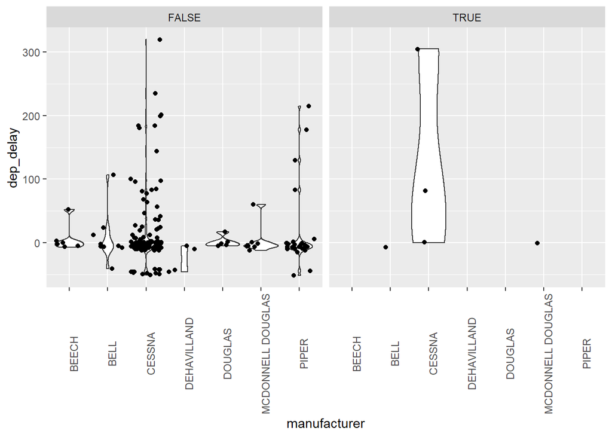

```r
flights_weather_planes <- flights_weather_planes %>%
  mutate(raining = precip > 0) %>%
  filter(complete.cases(.))

flights_weather_planes %>%
  ggplot(mapping = aes(x = manufacturer, y = dep_delay)) +
  geom_violin() +
  geom_jitter() +
  theme(axis.text.x = element_text(angle = 90)) +
  facet_wrap("raining")
```

Part 5: Insert an image of the coolest plane in the planes dataset (the choice is yours). Add a link to a webpage with some information on this super cool plane. Bonus points if your image is a GIF (not really bonus points but we’ll like it).

Enjoy this picture and website on the plane model ERJ145XR!

[figure not shown]

ERJ145XR

[ERJ145XR](https://www.embraercommercialaviation.com/commercial-jets/erj145xr/)